# Are Economic Indicators and Per Capita Carbon Dioxide Emissions Good Predictors of Human Development Index?

*Kasvina Tirumal (kasvina@uw.edu)*

## Research Questions and Summary

1. **How have a country’s per capita Gross Domestic Product (GDP), carbon dioxide (CO2) emissions, and Human Development Index (HDI) changed from 2010 to 2022? How have the top countries in each metric changed from 2010 to 2022?**

   For per capita GDP, **Luxembourg, Norway and Switzerland** were in the top 5 for both years. While Qatar and San Marino were previously ranked among the top 5 in 2010, they were replaced by Ireland and Singapore in 2022. For per capita CO2 emissions, **Qatar, Trinidad and Tobago, and the United Arab Emirates** remained in the top 5, with Kuwait and Aruba being replaced by Bahrain and Saudi Arabia in 2022. For HDI, **Switzerland, Norway and Iceland** remained in the top 5, with Germany and Austrailia being replaced by Denmark and Sweden in 2022.

   We also found that countries with higher GDP per capita tend to higher CO2 emissions per capita and HDI.
2. **Is there a difference in HDI across different per capita CO2 emission levels (Low, Medium, High) in 2022?**

   We found **significant variaton in HDI** across different per capita CO2 emission levels, as evidenced by the extremely small p-value and large F-statistic from the one-way ANOVA test conducted.
3. **How well do economic indicators predict HDI, and which indicators are the most important?**

## Challenge Goals

1. **Multiple Datasets**  
   Initially, we planned to only use 4 datasets for this project, which included: Economic Indicators, Per Capita CO2 Emissions, the Human Development Index, and Unemployment Rate. However, when exploring my initial combined dataset which combined the 4 aforementioned datasets, we found significant amounts of missing data, which would make training machine learning models difficult. Thus, we decided to impute missing values using the median value of each continent for the given year. This required an additional dataset with information on countries and its continent, named Continents. Consequently, the aforementioned 4 datasets will be combined with Continents, resulting in a total of **5 datasets** for this project.
2. **Statistical Hypothesis Testing**  
   Since we plan to use per capita CO2 emissions to predict HDI, we will first conduct a hypothesis test to determine whether there is a statistically significant difference in HDI across different per capita CO2 emission levels. To achieve this, We will perform a **one-way ANOVA test**, and categorize per capita CO2 emissions of each country into Low, Medium and High, depending on the distribution of the column, using the 33rd and 66th percentile as thresholds.
3. **Advanced Machine Learning**  
   We plan to utilize and compare two machine learning models to answer the third and fourth research question, namely **linear regression** and **XGBoost**. For each model type, we will train two separate models, one predicitng HDI using solely economic indicators, and the other using both economics indicators and per capita CO2 emissions. Furthermore, we will conduct **hyperparamter-tuning** on the XGBoost model using cross validation to maximize its accuracy.
4. **New Library**  
   Three new libraries will be used in this project, which includes Plotly, SciPy, and XGBoost. To answer the first research question, **Plotly** will be used to create an interactive dashboard that visualizes each country's per capita GDP, CO2 emissions, and HDI values from 2010 to 2022 using a choropleth map. Next, **SciPy** will be used conduct a one-way ANOVA test to answer the second research question. Finally, **XGBoost** will be used to train a machine learning model, to answer the third and fourth research question.

## Collaboration and Conduct

Students are expected to follow Washington state law on the [Student Conduct Code for the University of Washington](https://www.washington.edu/admin/rules/policies/WAC/478-121TOC.html). In this course, students must:

- Indicate on your submission any assistance received, including materials distributed in this course.
- Not receive, generate, or otherwise acquire any substantial portion or walkthrough to an assessment.
- Not aid, assist, attempt, or tolerate prohibited academic conduct in others.

Update the following code cell to include your name and list your sources. If you used any kind of computer technology to help prepare your assessment submission, include the queries and/or prompts. Submitted work that is not consistent with sources may be subject to the student conduct process.

```python
your_name = "Kasvina Tirumal"
sources = [
    "Search: how to suppress pandas FutureWarning",
    "Result: https://stackoverflow.com/questions/77900971/pandas-futurewarning-downcasting-object"
    "-dtype-arrays-on-fillna-ffill-bfill",
    "Search: how to convert data from long to wide format python. Answer: df.pivot()",
    "Result: https://stackoverflow.com/questions/22798934/pandas-long-to-wide-reshape"
    "-by-two-variables"
    "Search: how to convert a string column to float in pandas. Answer: pd.to_numeric",
    "Result: https://stackoverflow.com/questions/16729483/converting-strings-to-floats"
    "-in-a-dataframe",
    "Search: how to plot choropleth using plotly python. Functions: px.choropleth,"
    "fig.update_layout",
    "Result: https://plotly.com/python/choropleth-maps/",
    "Search: how to remove empty subplot from figure. Answer: fig.delaxes",
    "Result: https://stackoverflow.com/questions/44980658/remove-the-extra-plot-in"
    "-the-matplotlib-subplot",
    "Search: how to plot correlation heatmap in python. Answer: sns.heatmap",
    "Result: https://www.geeksforgeeks.org/how-to-create-a-seaborn-correlation-"
    "heatmap-in-python/",
    "Search: how to get top 5 largest numbers in column. Answer: df['column'].nlargest(n=5)",
    "Result: https://stackoverflow.com/questions/47462690/how-to-get-top-5-values-from"
    "-pandas-dataframe",
    "Search: how to choose columns based on data types in python. Asnwer: df.select_dtypes()",
    "Result: https://www.geeksforgeeks.org/select-columns-with-specific-data-types-in-"
    "pandas-dataframe/",
    "Search: how to get quantiles in python. Answer: df['col'].quantitle(x)",
    "Result: https://www.statology.org/pandas-quartiles/",
    "Search: how to condict one way anova test in python. Answer: f_oneway",
    "Result: https://www.geeksforgeeks.org/how-to-perform-a-one-way-anova-in-python/"
    "Search: what is xgboost in python",
    "Result: https://xgboost.readthedocs.io/en/stable/python/python_intro.html",
    "Search: how to tune xgboost hyperparameters",
    "Result: https://medium.com/@rithpansanga/optimizing-xgboost-a-guide-to"
    "-hyperparameter-tuning-77b6e48e289d",
    "Search: how to change 2d array to 1d python. Asnwer: array.flatten()",
    "Result: https://www.geeksforgeeks.org/python-flatten-a-2d-numpy-array-into-1d-array/",
    "Search: how to suppress pip install output",
    "Result: https://stackoverflow.com/questions/14616779/quiet-output-from-pip-via-requirements-file",
    "Search: how to test two dataframes are the same. Answer: assert_frame_equal()",
    "Result: https://saturncloud.io/blog/how-to-confirm-equality-of-two-pandas-dataframes/",
    "df.replace: https://pandas.pydata.org/docs/reference/api/pandas.DataFrame.replace.html",
    "Found plt.tight_layout while looking through the matplotlib website: ",
    "Link: https://matplotlib.org/stable/api/_as_gen/matplotlib.pyplot.tight_layout.html",
    "Indexing and filtering dataframes from lecture: data-frames.ipynb, "
    "groupby-and-indexing.ipynb",
    "Melt function from education assessment: education.ipynb",
    "reset_index() from section: groupby-and-data-viz.ipynb",
    "List comprehension from lecture: data-structures.ipynb",
    "Merging datasets from lecture: dissolve-intersect-and-join.ipynb",
    "creating figures and subplots from lecture: geospatial-data-frames.ipynb",
    "loop unpacking using zip from lecture: csv-data.ipynb",
    "df.groupby from lecture: groupby-and-indexing.ipynb",
    "lambda function from lecture: objects.ipynb",
    "machine learning code and functions from lecture:",
    "learning-algorithms.ipynb, model-evaluation.ipynb",
    "This includes creating X and y, performing train test split,"
    "pd.get_dummies, basic regression using linear regression, code for"
    "recursice feature elimination and cross validation using GridSearchCV.",
    "Use of None for optional function parameters: asymptotic-analysis.ipynb",
    "Used the plotly_to_html.ipynb resource provided by TAs to get plotly",
    "visualizations to show up in html format"
]


assert your_name != "", "your_name cannot be empty"
assert ... not in sources, "sources should not include the placeholder ellipsis"
assert len(sources) >= 6, "must include at least 6 sources, inclusive of lectures and sections"
```

## Data Setting and Methods

### About the Data

For this project, the `Economic Indicators` dataset was the primary dataset used, and was retrieved from the International Monetary Fund (IMF) website. This dataset contains 8624 rows and 60 columns, with each country’s data being represented by 44 rows, each corresponding to a unique economic indicator or the same indicator measured in different units. The dataset contains the following columns: `WEO Country Code`, `ISO`, `WEO Subject Code`, `Country`, `Subject Descriptor`, `Subject Notes`, `Units`, `Scale`, `Country/Series-specific Notes`, Years 1980 to 2029 (inclusive), and `Estimates Start After`.

The other **4** datasets were sourced from Our World in Data. The `Per Capita CO2 Emissions`, `Human Development Index` and `Unemployment Rate` datasets contained multiple rows per country, with a varying number of rows depending on the available time frame for the respective statistic of that country. Each row in the `Continents` dataset corresponds to a unique country. The `Human Development Index`, `Unemployment Rate` and `Continents` datasets share the same 4 columns: `Entity`, `Code`, `Year`, and their respective statistics, whereas the `Per Capita CO2 Emissions` dataset includes the same columns except for `Code`.

Below are links to the datasets used:

1. Economic Indicators: https://www.imf.org/en/Publications/WEO/weo-database/2024/October
2. Per Capita CO2 Emissions: https://ourworldindata.org/grapher/co-emissions-per-capita
3. Human Development Index: https://ourworldindata.org/grapher/human-development-index
4. Unemployment Rate: https://ourworldindata.org/grapher/unemployment-rate
5. Continents: https://ourworldindata.org/grapher/continents-according-to-our-world-in-data

### Data Preprocessing Plan

1. The `Economic Indicators` dataset, henceforth referred to as the **main dataset**, contains 44 rows of indicator information per country. To simplify analysis, the following **nine** economic indicators were selected based on macroeconomic knowledge: GDP per capita `NGDPDPC`, Investment `NID_NGDP`, Gross National Savings `NGSD_NGDP`, Inflation `PCPIPCH`, Volume of Imports `TM_RPCH`, Volume of Exports `TX_RPCH`, Unemployment Rate `LUR`, Population `LP`, and Implied Purchasing Power Parity (PPP) Conversion Rate `PPPEX`. Furthermore, indicators recorded in multiple units were standardized for consistency across countries.
2. The main dataset includes projections through 2029. While we considered excluding all estimated years, this would have removed too many observations, especially for smaller countries with estimates starting as early as 2003. To maximize data completeness, the range of analysis was chosen to be from the year 2010 to 2022, as most countries have non-estimated data through 2022.
3. The main dataset is structured with years as columns and indicators as the rows which complicates analysis. To solve this, the dataset will be reshaped so that years become rows and indicator values become columns.
4. The main dataset will be merged with the other 4 datasets using a left join. The `Per Capita CO2 Emissions`, `Human Development Index`, and `Unemployment Rate` datasets are merged with the main dataset on `Country` and `Year`, while the `Continents` dataset is merged on only `Country`.
5. After completing visualizations for research question 1, missing values with the main dataset will be imputed using the median of the continent that each country belongs to for the given year.

### Data Retrieval

```python
import pandas as pd
```

```python
econ_indicators = pd.read_csv("economic-indicator.csv")
co2_emissions = pd.read_csv("co2-emissions.csv")
hdi = pd.read_csv("hdi.csv").drop(columns='Code')
unemployment_rate = pd.read_csv("unemployment-rate.csv").drop(columns='Code')
continents = pd.read_csv("continents.csv").drop(columns=['Code', 'Year'])
```

### Data Preprocessing

We first remove the last two rows from our main dataset, which do not contain relevant data.

```python
econ_indicators = econ_indicators.iloc[:-2]
```

The dataset is then cleaned, merged, and pivoted, to ensure it is in the aforementioned desired format.

```python
def clean_merge_and_pivot(df):
    """
    Takes in a dataset df and filters it to only include rows
    with the following nine economic indicators found under the
    "WEO Subject Code" column: "NGDPDPC", "NID_NGDP", "NGSD_NGDP",
    "PCPIPCH", "TM_RPCH", "TX_RPCH", "LUR", "LP", and "PPPEX".
    The dataset is then transformed into a long format with "Year"
    as a single column, and then pivoted back to a wide format where
    each WEO Subject Code and their respective values become separate
    columns. The resulting dataset with its index reset is then returned.
    Assumes that the given df includes the columns "WEO Subject Code",
    "ISO", "Country", and multiple year columns.
    """
    codes = ["NGDPDPC", "NID_NGDP", "NGSD_NGDP", "PCPIPCH", "TM_RPCH",
             "TX_RPCH", "LUR", "LP", "PPPEX"]
    # filters the dataset to only include rows with the WEO Subject Codes
    # listed in codes
    df = df.loc[df["WEO Subject Code"].isin(codes), :]

    # sets up relevant years as string for analysis
    years = [str(year) for year in range(2010,2023)]
    years_str = [year for year in years if year in df.columns]

    # converts the dataset from wide to long format
    df_melted = df.melt(
        id_vars=["ISO","Country","WEO Subject Code"],
        value_vars=years_str,
        var_name="Year", value_name="Value"
    )

    # converts the dataset from long to wide format
    df_pivoted = df_melted.pivot(
        index=["ISO","Country","Year"],
        columns="WEO Subject Code", values="Value"
    )
    return df_pivoted.reset_index() # resets index


econ_df = clean_merge_and_pivot(econ_indicators)
```

Next, we remove non-numeric characters from columns representing numeric values, and convert them into a numeric data type.

```python
def convert_numeric(df):
    """
    Takes in a dataset df, and processes all columns starting from
    the third columns onwards. Non-numeric characters from values
    within these columns are removed, and converted into a numeric
    data type. Values that cannot be converted to a numeric data
    type are set to NaN. The resulting dataset is returned.
    Assumes that the given df has at least 3 columns.
    """
    for col in df.columns[2:]:
        # strips non-numeric characters from the column values
        df[col] = df[col].replace("[^0-9.]", "", regex=True)
        df[col] = pd.to_numeric(df[col], errors="coerce")
    return df


econ_df_num = convert_numeric(econ_df)
```

We then filter our dataset so that it only contains years between 2010 and 2022 (inclusive), which is our aforementioned range of analysis.

```python
def filter_relevant_years(df):
    """
    Takes in a dataset df, and filters the dataset to include only
    rows where values under the "Year" column fall within the range
    2010 to 2022 (inclusive). The filtered dataset is returned.
    Assumes that the given df contains a column named "Year".
    """
    years_int = [year for year in range(2010,2023)]
    return df.loc[df["Year"].isin(years_int)]


co2_filtered = filter_relevant_years(co2_emissions)
hdi_filtered = filter_relevant_years(hdi)
unemp_filtered = filter_relevant_years(unemployment_rate)
```

Next, we clean the remaining 4 datasets by renaming their respective statistic columns to shorter names, which improves readability and simplifies future analysis.

```python
def rename_col(df, old_name, new_name):
    """
    Takes in a dataset df, old_name, and new_name, and renames
    a column in the dataset from the given old_name to the given
    new_name. The renamed dataset is returned.
    Assumes the given dataset has a column with the given old_name.
    """
    return df.rename(columns={old_name: new_name})


co2_renamed = rename_col(co2_filtered, "Annual CO₂ emissions (per capita)", "CO2")
hdi_renamed = rename_col(hdi_filtered, "Human Development Index", "HDI")
unemp_renamed = rename_col(unemp_filtered, "Unemployment, total "
                "(% of total labor force) (modeled ILO estimate)", "UR")
cont_renamed = rename_col(continents, "World regions according to OWID", "Continent")
```

Finally, the main dataset is merged with the other 4 datasets using a left join. The `Per Capita CO2 Emissions`, `Human Development Index`, and `Unemployment Rate` datasets is joined onto the main dataset using both `Country` and `Year` as keys, while the `Continents` dataset will be merged with the main dataset, using only `Country` as the key.

Additionally, we replace the `LUR` column within the combined dataset with unemployment rate data from the `Unemplyment Rate` dataset, because of the large number of missing values within the `LUR` column of the main dataset.

```python
def combine_datasets(df1, df2, l_keys, r_keys=None):
    """
    Takes in two dataset, df1 and df2, and left join keys l_keys,
    and optional right join keys r_keys. The datasets df1 and
    df2 are merged using a left join on the given l_keys and
    r_keys. If r_keys is not provided, we assume that the left
    and right join keys are identical. The resulting merged dataset
    with the "Entity" column dropped is returned.
    Assumes that the df1 and df2 contains the columns listed in
    l_keys and r_keys respecitevely. If r_keys was not provided,
    assumes that df2 contains the columns listed in l_keys.
    """
    if r_keys is None:
        r_keys = l_keys
    return pd.merge(df1, df2, how="left", left_on=l_keys, right_on=r_keys).drop(columns="Entity")


combined_1 = combine_datasets(econ_df_num, co2_renamed, ["Country","Year"], ["Entity","Year"])
combined_2 = combine_datasets(combined_1, hdi_renamed, ["Country","Year"], ["Entity","Year"])
combined_3 = combine_datasets(combined_2, unemp_renamed, ["Country","Year"],
                              ["Entity","Year"]).drop(columns="LUR")
combined_4 = combine_datasets(combined_3, cont_renamed, "Country", "Entity")
```

This following shows 5 randomly selected rows from our cleaned dataset, `econ_df`.

```python
econ_df = combined_4.copy()
econ_df.sample(n=5)
```

|  | ISO | Country | Year | LP | NGDPDPC | NGSD_NGDP | NID_NGDP | PCPIPCH | PPPEX | TM_RPCH | TX_RPCH | CO2 | HDI | UR | Continent |
| --- | --- | --- | --- | --- | --- | --- | --- | --- | --- | --- | --- | --- | --- | --- | --- |
| 1376 | LVA | Latvia | 2021 | 1.893 | 20847.70 | 21.076 | 25.003 | 3.239 | 0.481 | 15.061 | 9.045 | 3.838632 | 0.865 | 7.513 | Europe |
| 871 | GNQ | Equatorial Guinea | 2010 | 0.951 | 17167.17 | 22.398 | 42.643 | 5.346 | 271.515 | 29.520 | 2.697 | 5.384114 | 0.609 | 8.292 | Africa |
| 44 | ALB | Albania | 2015 | 2.881 | 3953.61 | 15.804 | 26.237 | 1.868 | 43.072 | 0.070 | 5.908 | 1.625643 | 0.797 | 17.193 | Europe |
| 950 | HND | Honduras | 2011 | 8.481 | 2074.15 | 17.992 | 26.000 | 6.762 | 8.479 | 9.035 | 5.686 | 1.037436 | 0.598 | 4.475 | North America |
| 463 | CMR | Cameroon | 2018 | 25.216 | 1585.96 | 15.710 | 19.538 | 1.064 | 223.166 | 2.055 | 1.481 | 0.396976 | 0.581 | 3.619 | Africa |

### Data Dictionary

The resulting `econ_df` is represented as a `pandas` `DataFrame` with the following columns:

- `ISO` is a unique code that indentifies each country.
- `Country` is the name of the country.
- `Year` is the calendar year in which data was recorded for a country.
- `LP` is the total population of a country.
- `NGDPDPC` is the gross domestic product per capita, expressed in current US dollars.
- `NGSD_NGDP` is a ratio of gross national savings in current local currency and GDP in current local currency.
- `NID_NGDP` is a ratio of total investment in current local currency and GDP in current local currency
- `PCPIPCH` is inflation rate, measured as the year-on-year percentage change in average consumer prices.
- `PPPEX` is the implied PPP conversion rate, expressed in national currency per current international dollar.
- `TM_RPCH` is the volume of imports of good and services.
- `TX_RPCH` is the volume of exports of good and services.
- `CO2` is the per capita annual carbon dixoide emissions, measured in metric tonnes.
- `HDI` is the human development index, which is a composite measure of human development in a country.
- `UR` is the unemployment rate of a country.
- `Continent` is the continent that a country belongs to.

## Results

```python
!pip install -q plotly
```

```python
!pip install -q xgboost
```

```python
import numpy as np
import plotly.express as px
import matplotlib.pyplot as plt
import seaborn as sns
import scipy.stats as stats
from sklearn.linear_model import LinearRegression
from sklearn.metrics import root_mean_squared_error
from sklearn.model_selection import train_test_split
from sklearn.feature_selection import RFE
from sklearn.model_selection import GridSearchCV
import xgboost as xgb
```

### RQ1: Changes in per capita GDP, CO2 emissions, and HDI of each country from 2010 to 2022

In this section, we examine the changes in per capita GDP, CO2 emissions, and HDI across countries worldwide from 2010 to 2022 (inclusive). The changes are visualized using a choropleth map for each metric over the given period.

```python
def plot_interactive_viz(df, col, title, file_name, legend=None):
    """
    Takes in a dataset df, column col, title, file_name and an optional
    legend, creates an interactive choropleth map of the values from
    the given col for each country, and saves the plot as an html file.
    The map includes an animation of the data from the year 2010 to 2022
    (inclusive). A diverging color scale of BrBG is used, and the map
    is titled using the given title.
    If a legend is provided, it is used to label the color scale. If not,
    the color scale will share the same label as the given col.
    The map is titled "Worldwide Per Capita GDP (2010-2022)" (if Per
    Capita GDP is the given col).
    Assumes that the given dataset has the columns "Country", "Year",
    and the given col.
    Assumes the given file_name contains no spaces.
    """
    fig = px.choropleth(
        df,
        locations="Country",
        locationmode="country names",
        color=col,
        hover_name="Country",
        animation_frame="Year",
        color_continuous_scale=px.colors.diverging.BrBG,
        title=f"Worldwide {title} (2010-2022)"
    )
    if legend is not None:
        fig.update_layout(coloraxis_colorbar_title=legend)
    fig.write_html(f"{file_name}.html")


plot_interactive_viz(econ_df, "NGDPDPC", "Per Capita GDP", "per_capita_gdp", "GDP ($)")
plot_interactive_viz(econ_df, "CO2", "Per Capita CO2 Emissions", "per_capita_co2", "CO2 (tonnes)")
plot_interactive_viz(econ_df, "HDI", "Human Development Index", "hdi")
```

```python
%%html
<iframe width="800" height="500" src="https://students.washington.edu/kasvina/per_capita_gdp.html"
frameborder="0" allow="accelerometer; autoplay; clipboard-write; encrypted-media; gyroscope;
picture-in-picture" allowfullscreen></iframe>

<iframe width="800" height="500" src="https://students.washington.edu/kasvina/per_capita_co2.html"
frameborder="0" allow="accelerometer; autoplay; clipboard-write; encrypted-media; gyroscope;
picture-in-picture" allowfullscreen></iframe>

<iframe width="800" height="500" src="https://students.washington.edu/kasvina/hdi.html"
frameborder="0" allow="accelerometer; autoplay; clipboard-write; encrypted-media; gyroscope;
picture-in-picture" allowfullscreen></iframe>
```

[interactive chart not shown]

From the above three plots, we observe a **positive correlation** between per capita GDP, CO2 emissions and HDI, where **countries with higher per capita GDP tended to have higher per capita CO2 emissions and HDI**. This relationship is not surprising, as a higher GDP per capita suggests greater economic contribution per individual, which implies increased economic activity, and therefore higher CO2 emissions. In addition, a greater economic output typically leads to higher levels of human satisfaction and development, resulting in higher HDI scores.

For per capita CO2 emissions, **Europe** leads as the **top emitter**, with Asia and North America also ranking as top emitters. Qatar stands out as an outlier, with significantly high per capita CO2 emissions from the year 2015 onwards, likely due to increased liquefied natural gas production. Similar with per capita GDP, **Africa** has the **lowest** per capita CO2 emissions.

Finally, **Europe** and **North America** had the **highest** HDI values in 2022, which are also the same regions with high CO2 emissions. Once again, **Africa** had the **lowest** HDI values throughout the observed time period.

Overall, we observe a strong link between economic development, environmental impact, and human development, where wealthier regions with higher per capita GDP, also had higher per capita CO2 emissions and HDI values. This also implies that it is more challenging for poorer countries, such as those in Africa, to attain higher HDI due to a lack of capital to strengthen their economies. Therefore, targeted policy intervention is essential to address the disparities between wealthier and poorer nations, so that human development can be improved in less affluent countries.

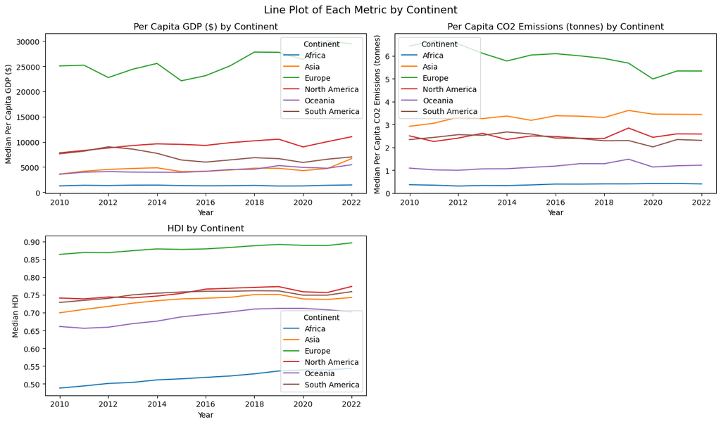

```python
def plot_line_chart(df):
    """
    Takes in a dataset df, and plots three line charts displaying
    the median values of Per Capita GDP, CO2 emissions, and HDI by
    continent from 2010 to 2022 (inclusive). Each plot displays
    six separate lines, each representing a different continent.
    The charts are arranged on a 2x2 grid, with two plots on the
    top row, and one on the left side of the bottom row.
    The titles of the plot from top to bottom, left to right, include
    "Per Capita GDP($) by Continent", "Per Capita CO2 Emissions (tonnes)
    by Continent", and "HDI by Continent". All three plots have the
    same x-axis label named "Year", while the y-axes are labeled
    "Median Per Capita GDP ($)", "Median Per Capita CO2 Emissions
    (tonnes)" and "Median HDI" respectively.
    The resulting 2x2 figure is displayed.
    Assumes the given df contains the columns "NGDPDPC", "CO2", "HDI",
    "Year" and "Continent".
    """
    cols = ["NGDPDPC", "CO2", "HDI"]
    titles = ["Per Capita GDP ($)", "Per Capita CO2 Emissions (tonnes)", "HDI"]
    data = df.groupby(["Continent", "Year"])[cols].median().reset_index()

    fig, axes = plt.subplots(2, 2, figsize=(13.5, 8))
    # flatten array to iterate over it
    axes = axes.flatten()
    for ax, col, title in zip(axes[:3], cols, titles):
        sns.lineplot(data=data, x="Year", y=col, ax=ax, hue="Continent")
        ax.set(
            title=f'{title} by Continent',
            xlabel="Year", ylabel=f"Median {title}"
        )
    # remove empty subplot
    fig.delaxes(axes[3])
    fig.suptitle("Line Plot of Each Metric by Continent", fontsize=14)
    plt.tight_layout()
    plt.show()


plot_line_chart(econ_df)
```

Next, while most continents had a consistent level of per capita CO2 emissions from 2010 to 2022 with periods of rise and falls, **Europe saw an overall decrease in its emissions**, likely due to the implementation of policies aimed at reducing emissions, such as the EU Renewable Energy Directive.

Another interesting observation is that **Asia**, despite having lower per capita GDP and HDI compared to other continents, had **relatively high median per capita CO2 emissions**. This suggests that production in Asia is less environemntally efficient than other continents, as it generates substantial emissions, without a proportional contribution to economic output or HDI, which is a common trend across developing countries. As a result, Asian countries should explore methods to enhance both their economic performance and HDI while minimizing carbon footprint.

Next, we examine the changes in per capita GDP, CO2 emissions, and HDI on a country-level by examining whether the top 5 countries in each metric have changed from 2010 to 2022.

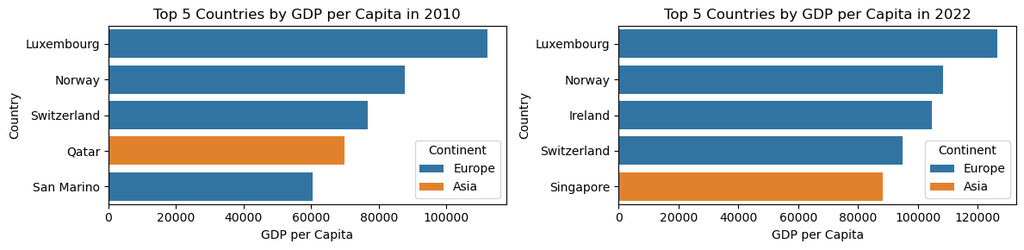

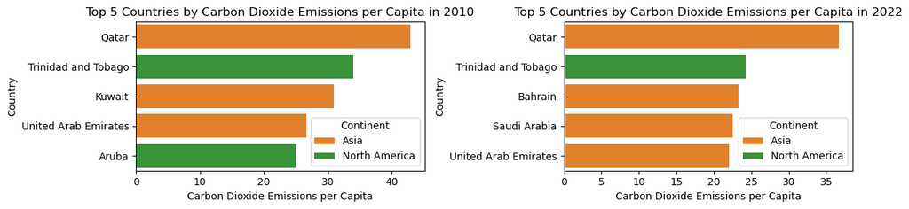

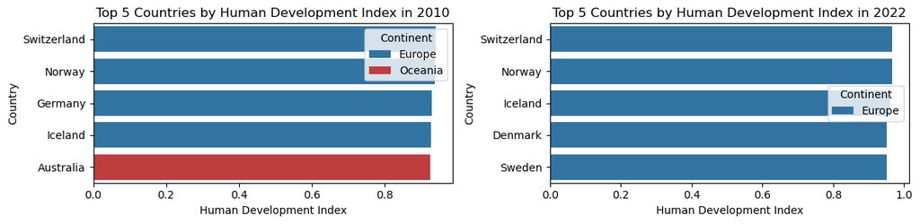

```python
def plot_top_5(df, col, x_axis):
    """
    Takes in a dataset df, column col, and x-axis label x_axis,
    and plots 2 bar charts on a 1x2 grid, one showing the top 5
    countries based on the given for the year 2010, and the other
    for the year 2022. In each plot, the bars are colored according
    to continent. The x-axis of the plot is labeled x_axis, the
    y-axis is labeled countries, and the plot contains a legend.
    The resulting 2x1 figure is displayed.
    Assumes the given df contains the columns "Year", "Country",
    "Continent", and the given col.
    """
    continents = ["Africa", "Asia", "Europe", "North America",
                  "South America", "Oceania"]
    color_codes = [4, 1, 0, 2, 5, 3]
    palette = {continent: sns.color_palette("tab10")[i]
               for continent, i in zip(continents, color_codes)}

    years = [2010, 2022]
    top_5_data = [df[df["Year"] == year].nlargest(5, col) for year in years]

    fig, axes = plt.subplots(1, 2, figsize=(12, 3))
    for ax, data, year in zip(axes, top_5_data, years):
        sns.barplot(
            data=data, x=col, y="Country",
            ax=ax, hue="Continent", palette=palette, legend=True
        )
        ax.set(
            title = f'Top 5 Countries by {x_axis} in {year}',
            xlabel = x_axis, ylabel = "Country"
        )
    plt.tight_layout()
    return axes


plot_top_5(econ_df, "NGDPDPC", "GDP per Capita")
plot_top_5(econ_df, "CO2", "Carbon Dioxide Emissions per Capita")
# semi-colon at the end to suppress array output
plot_top_5(econ_df, "HDI", "Human Development Index");
```

From the six plots above, we notice changes in the top 5 countries for each metric. For per capita GDP, **Luxembourg, Norway and Switzerland** remained in the top 5, while Qatar and San Marino dropped off, replaced by Ireland and Singapore. In both 2010 and 2022, the top 5 consisted of 4 European countries and 1 Asian country.

For per capita CO2 emissions, **Qatar, Trinidad and Tobago, and the United Arab Emirates** remained in the top 5. Kuwait and Aruba were replaced by Bahrain and Saudi Arabia. Interestingly, Qatar, the United Arab Emirates, and Saudi Arabia are all neigbouring countries, and share high CO2 emissions, possibly due to their high reliance on fossil fuels. In 2010, the top 5 included 3 Asian countries and 2 North American countries, whereas by 2022, there were 4 Asian countries and 1 North American country.

For HDI, the 2022 top 5 was dominated by the following European countries: **Switzerland, Norway, Iceland**, Denmark, and Sweden. While Germany and Australia were part of the top 5 in 2010, they were replaced by Denmark and Sweden, with the 2010 top 5 consisting of 4 European countries and 1 Oceanian country. It is not surprising that European countries dominate the top spots in HDI, as they have a strong focus on social welfare, leading to higher standards of living and life expectancy within European countries.

Overall, it is evident that **European countries dominate in per capita GDP and HDI rankings**, while the high per capita CO2 emissions in Asian countries reflect the region's continued industrialization between 2010 and 2022.

Finally, we plot a correlation heatmap to examine whether per capita GDP, CO2 emissions, and HDI are indeed positively correlated, as inferenced from the above visualizations.

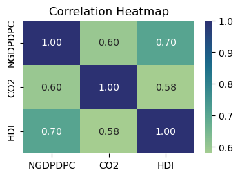

```python
def plot_corr_map(df):
    """
    Takes in a dataset df, and calculates the correlation matrix
    between Per Capita GDP, CO2 emissions, and HDI. A heatmap titled
    "Correlation Heatmap" is then displayed, with the correlation
    values annotated on the heatmap with two decimal places.
    Assumes the given df contains the columns "NGDPDPC", "CO2",
    and "HDI".
    """
    data = df[["NGDPDPC", "CO2", "HDI"]]
    corr = data.corr()

    # plot heatmap
    plt.figure(figsize=(4,2.5))
    sns.heatmap(corr, annot=True, cmap="crest", fmt=".2f")
    plt.title("Correlation Heatmap")
    plt.show()


plot_corr_map(econ_df)
```

We can conclude the following from the above heatmap:

- Per capita GDP and per capita CO2 emissions have a moderate postive correlation of 0.6.
- Per capita GDP and HDI have a moderate postive correlation of 0.7.
- Per capita CO2 emissions and HDI have a moderate postive correlation 0.58.
- The linear relationship between per capita GDP and HDI is stronger than that between per capita CO2 emissions and HDI.
- Both per capita GDP and CO2 emissions are essential in determining HDI.

The moderate postive correlation observed across the three variables align with our previous findings, where we infered that countries with higher per capita GDP tend to have higher per capita CO2 emissions and HDI. Therefore, **we can expect both per capita GDP and CO2 emissions to be important predictors of HDI**.

### RQ2: Statistical Analysis of Variation in HDI Across CO2 Emission Levels

In this section, we will perform a hypothesis test to determine whether there is a statistically significant difference in HDI values across different per capita CO2 emission levels in 2022. The hypotheses are as follows:

- Null hypothesis: HDI values do not differ across CO2 emission levels in 2022
- Alternative hypothesis: HDI values differ across CO2 emission levels in 2022

We start by imputing missing values within our dataset `econ_df`, using the median values of their respective continent for the given year. Instead of dropping these rows, we opted to impute missing values as we wanted to perserve valuable information from other columns, which would be especially imoprtant when training our machine learning models.

```python
def impute(df):
    """
    Takes in a dataset df, and imputes missing values within numerical
    columns of the dataset by replacing them with the median value of
    the continent that this country belongs to for that given year.
    The resulting dataset is returned.
    Assumes the given df contains the columns "Continent" and "Year".
    """
    numerical_cols = df.select_dtypes(include=[np.number])
    for col in numerical_cols:
        group = df.groupby(["Continent", "Year"])[col]
        df[col] = group.transform(lambda x: x.fillna(x.median()))
    return df


# drops rows where values are still missing after imputation
econ_imputed = impute(econ_df).dropna()
econ_df_2022 = econ_imputed[econ_imputed["Year"]==2022].copy()
```

Next, a new column named `CO2_Level` is added to the `econ_df_2022` dataset, that categorizes per capita CO2 emissions into Low, Medium, or High using its 33rd and 66th percentile thresholds.

```python
def categorize(df, col):
    """
    Takes in a dataset df and a column col, and creates a new
    column named "CO2_Level" (if the given col is CO2), then
    categorizes values in the given col into three levels:
    Low, Medium or High. Values less than or equal to the 33th
    percentile are categorized as Low, values between the 33th
    and 66th percentile (inclusive) are categorized as Medium,
    and the rest are categorized as High.
    The resulting dataset with the new column is returned.
    Assumes the given df contains the given col.
    """
    low = df[col].quantile(0.33)
    high = df[col].quantile(0.66)

    new_col = f"{col}_Level"
    df[new_col] = 'Low'
    df.loc[(df[col] > low) & (df[col] <= high), new_col] = 'Medium'
    df.loc[df[col] > high, new_col] = 'High'
    return df


econ_2022 = categorize(econ_df_2022, "CO2")
```

A boxplot is then created to visualize the distribution of HDI values across each CO2 emission level category.

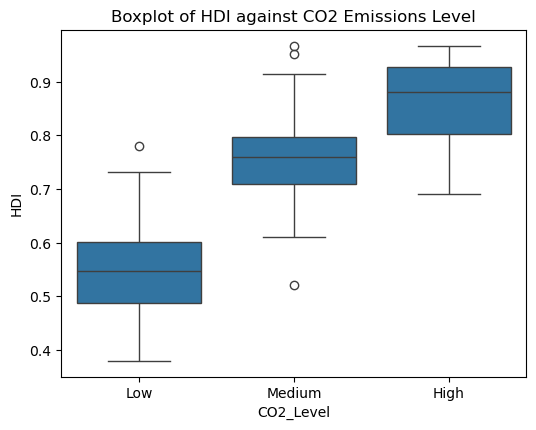

```python
def plot_hdi_boxplot(df, col, title):
    """
    Takes in a dataset df, a column col, and a title, and plots
    a boxplot displaying the distribution of HDI values for
    different categories of the given col, with the given title.
    The x-axis is labeled "CO2_Level" (if the given col is
    CO2_level), and the y-axis is labeled "HDI".
    The categories on the x-axis are ordered as 'Low', 'Medium',
    and 'High'. The resulting boxplot is displayed.
    Assumes the given df contains the column "HDI" and the given col.
    """
    plt.figure(figsize=(6, 4.5))
    sns.boxplot(x=col, y="HDI", data=df, order=["Low", "Medium", "High"])
    plt.title(title)


plot_hdi_boxplot(econ_2022, "CO2_Level", "Boxplot of HDI against CO2 Emissions Level")
```

The box plot above again **confirms the positive correlation between per capita CO2 emissions and HDI**, where median HDI increases as CO2 emissions level increase from Low to High. Furthermore, the spread of HDI values appear to shrink as CO2 emission levels increase, as evidenced by the shorter whiskers. In addition, the Medium CO2_Level has the most outliers of three, while the Low CO2_Level has one, followed by High which has none.

Overall, this visualization **provides us the intuition that HDI values may vary across CO2 emission levels**. To formally test this observation, we perform a one-way ANOVA test as shown below.

```python
def one_way_anova(df, col):
    """
    Takes in a dataset df, and column col, and performs a one-way
    ANOVA test to compare the means of HDI values across different
    categories of the given column. The results of the ANOVA test
    is returned as a tuple that includes the F-statistic and p-value.
    Assumes the given df contains the column "HDI" and the given col.
    """
    samples = []
    for level, agg_values in df.groupby(col):
        hdi_values = agg_values["HDI"].values
        samples.append(hdi_values)
    return stats.f_oneway(*samples)


F_stat, p_val = one_way_anova(econ_2022, "CO2_Level")
print(f"F-statistic: {F_stat}")
print(f"P-value: {p_val}")
```

```
F-statistic: 220.27601993369578
P-value: 8.375579621398576e-48
```

The ANOVA test results in a p-value of $8.38 \times 10^{-48}$, which is way smaller than the significance level of 0.05. Consequently, **we reject our null hypothesis** that HDI values do not differ across CO2 emission levels in 2022. Furthermore, our F-statistic is exceptionally large, reinforcing that HDI does indeed vary significantly across different per capita CO2 emission levels. This is likely because countries with higher per capita CO2 emissions tend to be more economically developed, and thus have invested more into human development, and therefore have higher HDI.

This significant varation of HDI across different CO2 emission levels further suggests that **per capita CO2 emissions will be a key predictor of HDI**.

### RQ3: Predicting HDI using Economic Indicators

In this section, we aim to predict HDI using only economic indictors. Consequently, our feature matrix `X` will include the nine economic indicators and `Year`, while the target variable `y` consist of HDI values. `Year` was included as a predictor to allow the model to capture temporal changes in economic indicators and HDI throughout the time period. A train-test split of 60-40 is employed, where 60% of the data is used to train the regression models, and the remaining 40% for testing.

```python
X = pd.get_dummies(econ_imputed.drop(["ISO", "Country", "Continent", "CO2", "HDI"], axis=1))
y = econ_imputed["HDI"]
X_train, X_test, y_train, y_test = train_test_split(X, y, test_size=0.4, random_state=2025)

lreg_model = LinearRegression()
xgb_model = xgb.XGBRegressor(random_state=25)
```

We start by training a basic linear regression model and an XGBoost model on the training set (`X_train`, `y_train`), and evaluate their performance on the test set `y_test` using the root mean squared error (RMSE).

```python
def basic_reg(X, y, model, name):
    """
    Fits a regression model of the given model type to the
    given feature matrix X and given target vector y. The
    RMSE of the model's predictions on the test set is then
    calculated. The RMSE is then printed using the given name,
    and the trained model is returned.
    Assumes y_test is defined prior to running this function.
    """
    reg = model.fit(X, y)
    print(f"{name} Error:", root_mean_squared_error(y_test, reg.predict(X_test)))
    return reg


lin_reg = basic_reg(X_train, y_train, lreg_model, "Lin Reg")
xgb_reg = basic_reg(X_train, y_train, xgb_model, "XGBoost")
```

```
Lin Reg Error: 0.10590499482313503
XGBoost Error: 0.027452265786200008
```

The **basic XGBoost model performs better than the linear regression model**, as it achieves a smaller RMSE of 0.027, compared to 0.106 of the linear regression model.

This difference in performance could be due to several factors, the first being that the relationship between HDI and its predictors may be non-linear. Since XGBoost is a tree-based model, it can capture non-linear relationships more effectively, whereas linear regression stricty assumes a linear relationship, even when interaction terms are added to the model. Furthermore, XGBoost is more robust to outliers, allowing it to differentiate between meaningful patterns and noise more effectively than linear regression.

Next, we train a linear regression and XGBoost model using **recursive feature elimination (RFE)** to determine whether we can maintain the models' accuracy, while using fewer predictors. We want to train our models using the fewest possible predictors, so that users only need to provide minimal input to predict HDI.

**We expect the RMSE for both models to increase**, as the models now have fewer predictors to learn from.

```python
def rfe(X, y, model, name):
    """
    Performs recursive feature elimination (RFE) using a regression
    model of the given model type to select the top 5 features from
    the given feature matrix X and target vector y.
    The list of top 5 features and the RMSE of the model’s
    predictions on the test set are then printed out using the
    given name on two separate lines, followed by a blank line.
    The list of top 5 features is returned.
    Assumes y_test is defined prior to running this function.
    """
    rfe = RFE(model, step=1, n_features_to_select=5, verbose=1)
    rfe.fit(X, y)
    rfe_features = X.columns[[r == 1 for r in rfe.ranking_]]

    print(f"{name} Features:", list(rfe_features))
    print(f"{name} RFE Error:", root_mean_squared_error(y_test, rfe.predict(X_test)))
    print()
    return list(rfe_features)


lr_features = rfe(X_train, y_train, lreg_model, "Lin Reg")
xgb_features = rfe(X_train, y_train, xgb_model, "XGBoost")
```

```
Fitting estimator with 10 features.
Fitting estimator with 9 features.
Fitting estimator with 8 features.
Fitting estimator with 7 features.
Fitting estimator with 6 features.
Lin Reg Features: ['Year', 'NGSD_NGDP', 'NID_NGDP', 'TM_RPCH', 'UR']
Lin Reg RFE Error: 0.14266216833203763

Fitting estimator with 10 features.
Fitting estimator with 9 features.
Fitting estimator with 8 features.
Fitting estimator with 7 features.
Fitting estimator with 6 features.
XGBoost Features: ['LP', 'NGDPDPC', 'NID_NGDP', 'PPPEX', 'UR']
XGBoost RFE Error: 0.024364397231039513
```

The RMSE of the linear regression model trained using RFE is 0.143, which is expectedly higher than its previous RMSE of 0.106 using the basic model. Surprisingly, **the new XGBoost model achieves a smaller RMSE of 0.024 comapred to its previous value of 0.027**. This suggests that the XGBoost model performed better with fewer predictor (5 predictors), than when it had access to all predictors within `X_train`. One possible explanation is that when XGBoost had access to more predictors, it may have overfitted the data. Reducing the number of predictors allowed the model to learn more important patterns, which led to increased performance and predictive accuracy.

Next, we want to improve the accuracy of our XGBoost model by **tuning its hyperparameters**. More specifically, the following hyperparamters will be tuned: *learning rate*, *maximum depth*, *minimum child weight*, and *column sample by tree*. This is achieved through cross-validation, as demonstrated below. Note that the XGBoost model will be trained solely on `xgb_features`, which were the top 5 predictors identified by XGBoost using RFE.

**We expect the RMSE of the hyperparameter-tuned model to be lower than the model trained using RFE.**

```python
def cross_validation_xgb(features, X, X_train, X_test, y):
    """
    Takes in a list of features, and subsets the given matrices
    X, X_train and X_test to only include the given features.
    Hyperparamter tuning is then performed using cross-validation
    on an XGBoost regression model, with the following parameters
    being tuned: learning rate, maximum depth, minimum child weight,
    and column sample by tree. The model is trained on the subsetted
    X-train and given y. The best model is chosen based on the
    highest negative root mean squared error (RMSE) score. The mean
    score of the best model, the model's hyperparamters, and the most
    important features ranked by feature importance scores in
    descending order are printed. The trained XGBoost model with the
    tuned hyperparamters is returned.
    """
    X = X[features]
    X_train = X_train[features]
    X_test = X_test[features]
    param_grid={
        "learning_rate"    : [0.05, 0.10, 0.15, 0.2, 0.3],
        "max_depth"        : [3, 4, 5, 6, 7, 8, 10],
        "min_child_weight" : [1, 3, 6, 8, 10],
        "colsample_bytree" : [0.3, 0.5, 0.7, 0.8]
    }
    search = GridSearchCV(
        estimator=xgb.XGBRegressor(random_state=25),
        param_grid=param_grid,
        scoring="neg_root_mean_squared_error",
        n_jobs=-1,
        verbose=0,
    )
    search.fit(X_train, y)
    print("Mean score for best model:", search.best_score_)
    reg = search.best_estimator_
    print("Best model:", reg)

    # Prints feature importance scores in descending order
    fi_scores = pd.Series(reg.feature_importances_, index=features).sort_values(ascending=False)
    print("Most Important Features:\n" + fi_scores.to_string())
    return reg


xgb_reg = cross_validation_xgb(xgb_features, X, X_train, X_test, y_train)
```

```
Mean score for best model: -0.029796686531949685
Best model: XGBRegressor(base_score=None, booster=None, callbacks=None,
             colsample_bylevel=None, colsample_bynode=None,
             colsample_bytree=0.8, device=None, early_stopping_rounds=None,
             enable_categorical=False, eval_metric=None, feature_types=None,
             feature_weights=None, gamma=None, grow_policy=None,
             importance_type=None, interaction_constraints=None,
             learning_rate=0.1, max_bin=None, max_cat_threshold=None,
             max_cat_to_onehot=None, max_delta_step=None, max_depth=10,
             max_leaves=None, min_child_weight=8, missing=nan,
             monotone_constraints=None, multi_strategy=None, n_estimators=None,
             n_jobs=None, num_parallel_tree=None, ...)
Most Important Features:
NGDPDPC     0.694425
PPPEX       0.149020
UR          0.058827
LP          0.049915
NID_NGDP    0.047813
```

```python
print("XGBoost CV Error:", root_mean_squared_error(y_test, xgb_reg.predict(X_test[xgb_features])))
```

```
XGBoost CV Error: 0.025625419385489404
```

**The hyperparamter-tuned XGBoost model achieves an RMSE score of 0.026, which is surprisingly higher than the RMSE of 0.024 achieved through RFE**. The new RMSE is slightly lower than the basic XGBoost model which used all avaliable predictors, and achieved an RMSE of 0.027.

**Therefore, the most accurate model for predicting HDI using economic indicators is the XGBoost model trained using RFE, `xgb_features`.**

### RQ4: Predicting HDI using Economic Indicators and CO2 Emissions

In this section, we again train an XGBoost model to predict HDI using RFE and perform hyperparameter tuning through cross-validation, with the only difference being the **inclusion of per capita CO2 emissions `CO2` as a predictor**. We aim to identify the best model for predicting HDI and assess whether CO2 emissions is a significant predictor of HDI.

```python
X = pd.get_dummies(econ_imputed.drop(["ISO", "Country", "Continent", "HDI"], axis=1))
y = econ_imputed["HDI"]
X_train, X_test, y_train, y_test = train_test_split(X, y, test_size=0.4, random_state=2025)
xgb_co2_features = rfe(X_train, y_train, xgb.XGBRegressor(random_state=25), "XGBoost with CO2")
```

```
Fitting estimator with 11 features.
Fitting estimator with 10 features.
Fitting estimator with 9 features.
Fitting estimator with 8 features.
Fitting estimator with 7 features.
Fitting estimator with 6 features.
XGBoost with CO2 Features: ['LP', 'NGDPDPC', 'PPPEX', 'CO2', 'UR']
XGBoost with CO2 RFE Error: 0.021155222562325576
```

As seen above, the XGBoost model trained using RFE achieved an RMSE of 0.021, which is the lowest RMSE observed thus far. This suggests that **the inclusion of CO2 emissions significantly improved the model's ability to predict HDI**. This is further evidenced by the list of top 5 predictors selected by RFE, which includes per capita CO2 emissions `CO2`.

Next, we perform hyperparamter tuning on the XGBoost model trained using the top 5 predictors selected by RFE, which includes: `LP`, `NGDPDPC`, `PPPEX`, `CO2`, and `UR`.

```python
xgb_co2_reg = cross_validation_xgb(xgb_co2_features, X, X_train, X_test, y_train)
```

```
Mean score for best model: -0.022681838716496976
Best model: XGBRegressor(base_score=None, booster=None, callbacks=None,
             colsample_bylevel=None, colsample_bynode=None,
             colsample_bytree=0.8, device=None, early_stopping_rounds=None,
             enable_categorical=False, eval_metric=None, feature_types=None,
             feature_weights=None, gamma=None, grow_policy=None,
             importance_type=None, interaction_constraints=None,
             learning_rate=0.2, max_bin=None, max_cat_threshold=None,
             max_cat_to_onehot=None, max_delta_step=None, max_depth=10,
             max_leaves=None, min_child_weight=10, missing=nan,
             monotone_constraints=None, multi_strategy=None, n_estimators=None,
             n_jobs=None, num_parallel_tree=None, ...)
Most Important Features:
CO2        0.574652
NGDPDPC    0.343820
PPPEX      0.035601
LP         0.023962
UR         0.021965
```

Before we evaluate our model, note that the hyperparameter-tuned XGBoost model identified `CO2` as the most important predictor for HDI, as it has the **highest feature importance score of 0.57**. This suggests that `CO2` plays a crucial role in predicting HDI, and is thus an important predictor of HDI.

```python
print("XGBoost with CO2 CV Error:",
      root_mean_squared_error(y_test, xgb_co2_reg.predict(X_test[xgb_co2_features])))
```

```
XGBoost with CO2 CV Error: 0.02080412091809692
```

In contrast to the previous section, the hyperparameter-tuned XGBoost model achieves a smaller RMSE of 0.021 than RFE, which is the new lowest RMSE. Hence, **the most accurate model to predict HDI is the hyperparameter-tuned model `xgb_co2_reg`**, which includes per capita CO2 emissions, `CO2`, as a predictor.

#### Function for Users to Predict HDI using the Best Regression Model

As the final step, we create a function that allows users to input values for `LP`, `NGDPDPC`, `PPPEX`, `CO2`, and `UR` to predict HDI.

```python
def predict_HDI(lp, gdp, ppp, co2, ur, model):
    """
    Takes in user input values for five features: "LP", "NGDPDPC",
    "PPPEX", "CO2", and "UR". The given model is then used to
    predict the Human Development Index (HDI) based on the given
    inputs and returns the predicted HDI value as the output.
    """
    user_input = pd.DataFrame(
                    data = [[lp, gdp, ppp, co2, ur]],
                    columns=["LP", "NGDPDPC", "PPPEX", "CO2", "UR"]
                )
    return model.predict(user_input)[0]


# sample user input
print(f"Predicted HDI:", predict_HDI(0.11, 25000, 1.35, 13.3, 7.1, xgb_co2_reg))
```

```
Predicted HDI: 0.8016532
```

## Implications and Limitations

From this project, we learned that per capita GDP, CO2 emissions, and HDI are positively correlated, and that both economic indicators and CO2 emissions serve as significant predictors of HDI.

The results of this project are valuable for those interested in improving a country's HDI, which includes academics, economists, policymakers, and local, state and governmental agencies. This is because stakeholders can use the predictive model to evaluate how changes in the values of different key predictors of HDI affect HDI, and select the optimal combination of predictor values that maximizes HDI while minimizing environmental impact and promoting economic growth. Policies can then be implemented to align real-word indicator values to match this optimal combination, which ultimately leads to a reliable improvement in HDI.

However, it is important to consider these results alongside the limitations of this analysis, which includes:

1. **Possible misinterpretation of results**

   Our analysis revealed a moderate positive correlation between HDI and per capita CO2 emissions, suggesting that higher CO2 emissions are associated with higher HDI. While this may seem counterintuitive since we expect increased pollution to reduce quality of life, and thus lower HDI, this correlation actually reflects the indirect relationship between economic activity and CO2 emissions, not the intentional increase of emissions. Consequently, these findings could be misused by those seeking to harm the environment, potentially leading to policies that increase CO2 emissions under the false belief that they improve HDI.
2. **Reliability of data**

   The main dataset used within this analysis, `Economic Indicators`, was sourced from the IMF website. This presents a limitation because the IMF works closely with governments worldwide to foster global monetary corporation. This monetary relationship incentivizes countries to misreport their data in ways that align with their economic interests, especially since these numbers affect the financial assistance they receive from the IMF. As a result, the dataset may be inaccurate or biased, which may have skewed the strength of correlation observed between per capita GDP, CO2 emissions and HDI. Consequently, policies derived from this analysis may not be as effective as projected. For future analysis, we will cross-check the IMF data with data from other sources such as the World Bank, to ensure that they are consistent and accurate.
3. **Completeness of data**

   The `Economic Indicators` dataset contained a significant number of missing values, which were addressed through imputation, by using the median value of each continent for its respective year. However, it is important to consider that missing values were most prevalent among smaller and less developed countries. As a result, these countries should use the results of this analysis with caution, as the imputed data used to train the machine learning models may not best represent their economic and social trends. Conversely, this analysis is likely more accurate for developing and developed countries, since their data were typically more complete. For future analysis, instead of using the continent’s median for imputation, we will cross-check missing values with other databases to identify an exact value.
4. **Simplification of analysis**

   Our analysis was simplified by selecting only nine indicators out of the 44 available within the original `Economic Indicators` dataset. This selection was somewhat biased, as it was based on personal macroeconomic knowledge. Thus, it is likely that there may have been other important predictors of HDI that were unintentionally excluded from the analysis, which diminishes the accuracy of our findings. Thus, for future analysis, we will attempt to consider all 44 indicators, and identify the actual 5 most important predictors of HDI from them. This eliminates the possibility of missing important variables that correlate with HDI.
5. **Absence of `Year` as a predictor in the final model**

   When looking at the top 5 predictors of HDI identified by the XGBoost model that included `CO2` as a predictor, it is important to note that `Year` was not selected as a top 5 predictor. Consequently, `Year` was excluded as a parameter for users to input when estimating HDI. However, given that we expect the values of economic indicators, CO2 emissions, and HDI to change on a year-to-year basis, it seems illogical to not include `Year` as a parameter. Hence, for future analysis, the importance of `Year` as a predictor will be evaluated, to better understand our model and strengthen the analysis within this project.

## Testing

```python
import pandas.testing as pdt
```

```python
econ_small = pd.DataFrame({
    "ISO": ["USA", "USA", "USA", "HRV", "HRV", "HRV", "MEX", "MEX", "MEX",
           "DNK", "DNK", "DNK"],
    "Country": ["United States", "United States", "United States", "Croatia",
                "Croatia", "Croatia", "Mexico", "Mexico", "Mexico",
                "Denmark", "Denmark", "Denmark"],
    "WEO Subject Code": ["NGDPDPC", "NID_NGDP", "NGSD_NGDP", "NGDPDPC",
                         "NID_NGDP", "NGSD_NGDP", "NGDPDPC", "NID_NGDP",
                         "NGSD_NGDP", "NGDPDPC", "NID_NGDP", "NGSD_NGDP"],
    "2010": ["10,000", "200", "300", "50", "150.3", "a", "75", "175", "275",
            "400", "500.2", "601"],
    "2011": ["11,000", np.nan, "330", "55.4", "155", "2,550", np.nan, "185",
             "285.9", "435", "543", "654"]
})

co2_small = pd.DataFrame({
    "Entity": ["United States", "Croatia", "Algeria", "Algeria", "Guyana"],
    "Year": [1987, 2010, 2022, 2023, 2015],
    "Annual CO₂ emissions (per capita)": [7.4, 10.2, np.nan, 0.02, 1.2]
})

hdi_small = pd.DataFrame({
    "Entity": ["United States", "Croatia", "Algeria", "Algeria", "Guyana"],
    "Year": [1987, 2010, 2022, 2023, 2015],
    "Human Development Index": [0.8, 0.5, 0.2, np.nan, 0.3]
})

ur_small = pd.DataFrame({
    "Entity": ["United States", "Croatia", "Algeria", "Algeria", "Guyana"],
    "Year": [1987, 2010, 2022, 2023, 2015],
    "Unemployment, total (% of total labor force) (modeled ILO estimate)":
    [7.4, 10.2, 13.4, 14.1, np.nan]
})

cont_small = pd.DataFrame({
    "Entity": ["United States", "Croatia", "Algeria", "Algeria", "Guyana"],
    "World regions according to OWID":
    ["North America", "Europe", "Africa", "Africa", "South America"]
})
```

```python
def test_clean_merge_and_pivot():
    df_result = clean_merge_and_pivot(econ_small)
    df_result = df_result.rename_axis(None, axis=1)
    expected_df = pd.DataFrame({
        "ISO": ["DNK", "DNK", "HRV", "HRV", "MEX", "MEX", "USA", "USA"],
        "Country": ["Denmark", "Denmark", "Croatia", "Croatia",
                    "Mexico", "Mexico", "United States", "United States"],
        "Year": ["2010", "2011", "2010", "2011", "2010", "2011",
                 "2010", "2011"],
        "NGDPDPC": ["400", "435", "50", "55.4", "75", np.nan,
                    "10,000", "11,000"],
        "NGSD_NGDP": ["601", "654", "a", "2,550", "275", "285.9","300","330"],
        "NID_NGDP": ["500.2", "543", "150.3","155","175","185","200",np.nan]
    })
    pdt.assert_frame_equal(df_result, expected_df)

def test_convert_numeric():
    df = convert_numeric(clean_merge_and_pivot(econ_small))
    year_dtype = df["Year"].dtype
    expec_type = "int64"
    assert year_dtype == expec_type, (
        f"Expected {expec_type} data type for 'Year', but got {year_dtype}"
    )
    for col in df.columns[3:]:
        d_type = df[col].dtype
        expec_type = "float64"
        assert d_type == expec_type, (
            f"Expected {expec_type} data type for '{col}', but got {d_type}"
        )


def test_filter_relevant_years():
    co2_filt = filter_relevant_years(co2_small)
    hdi_filt = filter_relevant_years(hdi_small)
    ur_filt = filter_relevant_years(ur_small)
    expec_row = 3
    assert len(co2_filt) == expec_row, (
        f"Expected {expec_row} rows, but got {len(co2_filt)}"
    )
    assert len(hdi_filt) == expec_row, (
        f"Expected {expec_row} rows, but got {len(hdi_filt)}"
    )
    assert len(ur_filt) == expec_row, (
        f"Expected {expec_row} rows, but got {len(ur_filt)}"
    )


def test_rename_col():
    dfs = [co2_small, hdi_small, ur_small, cont_small]
    old_names = ["Annual CO₂ emissions (per capita)", "Human Development Index",
                 "Unemployment, total (% of total labor force) (modeled ILO estimate)",
                 "World regions according to OWID"]
    new_names = ["CO2", "HDI", "UR", "Continent"]

    for df, old_name, new_name in zip(dfs, old_names, new_names):
        renamed_df = rename_col(df, old_name, new_name)
        assert new_name in renamed_df.columns, f"Column '{new_name}' not found"
        assert old_name not in renamed_df.columns, (
            f"Column '{old_name}' still exists"
        )

def test_combine_datasets():
    df = convert_numeric(clean_merge_and_pivot(econ_small))
    # same left and right keys
    combined_df = combine_datasets(df, cont_small, "Country", "Entity")
    expected_df = pd.DataFrame({
        "ISO": ["DNK", "DNK", "HRV", "HRV", "MEX", "MEX", "USA", "USA"],
        "Country": ["Denmark", "Denmark", "Croatia", "Croatia",
                    "Mexico", "Mexico", "United States", "United States"],
        "Year": [2010, 2011, 2010, 2011, 2010, 2011, 2010, 2011],
        "NGDPDPC": [400, 435, 50, 55.4, 75, np.nan, 10000, 11000],
        "NGSD_NGDP": [601, 654, np.nan, 2550, 275, 285.9, 300, 330],
        "NID_NGDP": [500.2, 543, 150.3, 155, 175, 185, 200, np.nan],
        "World regions according to OWID":
        [np.nan, np.nan, "Europe", "Europe", np.nan, np.nan,
         "North America", "North America"]
    })
    pdt.assert_frame_equal(combined_df, expected_df)

    # different left and right keys
    combined_df_2 = combine_datasets(df, co2_small, ["Country","Year"],
                                     ["Entity","Year"])
    expected_df_2 = pd.DataFrame({
        "ISO": ["DNK", "DNK", "HRV", "HRV", "MEX", "MEX", "USA", "USA"],
        "Country": ["Denmark", "Denmark", "Croatia", "Croatia", "Mexico",
                    "Mexico", "United States", "United States"],
        "Year": [2010, 2011, 2010, 2011, 2010, 2011, 2010, 2011],
        "NGDPDPC": [400, 435, 50, 55.4, 75, np.nan, 10000, 11000],
        "NGSD_NGDP": [601, 654, np.nan, 2550, 275, 285.9, 300, 330],
        "NID_NGDP": [500.2, 543, 150.3, 155, 175, 185, 200, np.nan],
        "Annual CO₂ emissions (per capita)":
        [np.nan, np.nan, 10.2, np.nan, np.nan, np.nan, np.nan, np.nan]
    })
    pdt.assert_frame_equal(combined_df_2, expected_df_2)


def test_impute():
    df_clean = convert_numeric(clean_merge_and_pivot(econ_small))
    cont_small = rename_col(continents, "World regions according to OWID", "Continent")
    df = combine_datasets(df_clean, cont_small, "Country", "Entity")
    imputed_df = impute(df)
    expected_df = pd.DataFrame({
        "ISO": ["DNK", "DNK", "HRV", "HRV", "MEX", "MEX", "USA", "USA"],
        "Country": ["Denmark", "Denmark", "Croatia", "Croatia", "Mexico",
                    "Mexico", "United States", "United States"],
        "Year": [2010, 2011, 2010, 2011, 2010, 2011, 2010, 2011],
        "NGDPDPC": [400, 435, 50, 55.4, 75, 11000, 10000, 11000],
        "NGSD_NGDP": [601, 654, 601, 2550, 275, 285.9, 300, 330],
        "NID_NGDP": [500.2, 543, 150.3, 155, 175, 185, 200, 185],
        "Continent": ["Europe", "Europe", "Europe", "Europe", "North America",
                      "North America", "North America", "North America"]
    })
    pdt.assert_frame_equal(imputed_df, expected_df)


def test_categorize():
    data = pd.DataFrame({"Emissions": [1, 2, 3, 4, 5, 6, 7, 8, 9]})
    cat_df = categorize(data, "Emissions")
    expected_df = pd.DataFrame({
        "Emissions": [1, 2, 3, 4, 5, 6, 7, 8, 9],
        "Emissions_Level": ["Low", "Low", "Low", "Medium", "Medium",
                           "Medium", "High", "High", "High"]
    })
    pdt.assert_frame_equal(cat_df, expected_df)
```

```python
test_clean_merge_and_pivot()
test_convert_numeric()
test_filter_relevant_years()
test_rename_col()
test_combine_datasets()
test_impute()
test_categorize()
```